# 大跌時買什麼產業最賺錢?，大波動的投資策略

# 投組報酬率計算

根據買進持有日期，持有天數，進行投資報酬計算

```r
#要進行回測的產業(或股票)
waited.stock_code = c("2412 中華電","0050 元大台灣50","2330 台積電","M11TR 水泥TR" , "M12TR 食品TR" , "M13TR 塑膠TR" , "M14TR 紡織TR" , "M15TR 電機機TR"
               ,"M16TR 電器電TR" , "M17T1 化學TR" , "M17T2 生技TR" , "M17TR 化學生TR" , "M17T2 生技TR" , "M18TR 玻璃TR" , "M19TR 造紙TR" , "M20TR 鋼鐵TR" ,
               "M21TR 橡膠TR" , "M22TR 汽車TR" , "M23T1 半導體報酬指數" , "M23T2 電腦及週邊設備業TR" , "M23T3 光電類TR" , "M23T4 通信網路類TR" ,
               "M23T5 電子零組件TR", "M23T6 電子通路業TR" , "M23T7 資訊服務業TR" , "M23T8 其他電子業TR" , "M23TR 電子報酬" , "M25TR 營造TR",
               "M26TR 航運TR" , "M27TR 觀光TR" , "M28TR 金融報酬" , "M29TR 百貨TR" , "M97TR 油電燃TR" , "M99TR 其他TR")

event_day = big_event_date  #事件日日期
ndays = c(1,7,20,60,120,252) #買入持有天數
```

```r
###測試使用
# ndays = c(1,7,20,60)
# n = 120
# i = c("M23T1 半導體報酬指數" )
# date = 20200130
# waited.stock_code = c("M23T1 半導體報酬指數" ,"M23T5 電子零組件TR")
# ndays = c(20,60)
###測試使用
```

```r
#篩選完Date之後，選出每檔前n筆資料
list = data.table()
period.report.sheet = data.table()
for (n in  ndays){
for (i in  waited.stock_code){
for (date in event_day){
single.stock = stock_price %>% filter(stock_code == i & 年月日 > date) %>% mutate(holding_days = n , #因為是用收盤價所以不是年月日 >= date，沒有等於代表後一天不包含當天
                                                                                   cumprod = cumprod(1+closed_price_daily_change)-1)
single.stock = single.stock[1:n,]
#加碼func >
buy_more = T
single.stock = buy_more_func(return = single.stock , buy_more = buy_more , n_part_money = 3 , buy_more_point = -0.05 )
#加碼func <
single.stock = single.stock %>% mutate(cumprod = cumprod(1+closed_price_daily_change)-1) #因為加碼func先把日報酬重算一遍了，所以要再重算一次複利

period.report = data.table( stock_code = last(single.stock$stock_code), #取最後一筆資料出來
                            #公司名稱 = last(single.stock$公司名稱),
                            #TSE產業別 = last(single.stock$TSE產業別),
                            買入日期 = first(single.stock$年月日),
                            買入持有天數 = n ,
                            標準差 = sd(single.stock$cumprod , na.rm = T) %>% round( digits = 4) ,
                            期間最大漲幅 = max(single.stock$cumprod) %>% round( digits = 4),
                            期間最大跌幅 = min(single.stock$cumprod) %>% round( digits = 4),
                            累積報酬率 = last(single.stock$cumprod) %>% round( digits = 4)
                    )

if (buy_more == T){ #設計表格的加碼欄位，有加碼的話再新增表格紀錄
  period.report = period.report %>% mutate(加碼次數 = last(single.stock$加碼次數))
}else{
  period.report = period.report %>% mutate(加碼次數 = "不加碼" )
}
period.report.sheet = rbind(period.report.sheet , period.report) #合併成每期間的報酬表
list = list %>% filter(!duplicated(list)) #移除重複值，怕重複
list = rbind(list ,  single.stock)
}}}
```

```r
period.report.sheet %>% arrange(desc(累積報酬率)) %>% head
```

```
##              stock_code 買入日期 買入持有天數 標準差 期間最大漲幅 期間最大跌幅
## 1:   M23T6 電子通路業TR 20090109          252 0.1197       0.4013      -0.0068
## 2:         M17T1 化學TR 20090109          252 0.0920       0.3000      -0.0115
## 3:       M17TR 化學生TR 20090109          252 0.0866       0.2769      -0.0110
## 4:       M23TR 電子報酬 20090109          252 0.0810       0.2788      -0.0150
## 5: M23T1 半導體報酬指數 20090109          252 0.0749       0.2665      -0.0144
## 6:         M25TR 營造TR 20090109          252 0.0910       0.2429      -0.0461
##    累積報酬率 加碼次數
## 1:     0.3892        0
## 2:     0.3000        0
## 3:     0.2769        0
## 4:     0.2739        0
## 5:     0.2608        0
## 6:     0.2429        2
```

```r
total.performance.sheet = data.table()
for (n in  ndays){
for (i in  waited.stock_code){

tmp = list %>% select(stock_code ,年月日 , closed_price_daily_change , holding_days) %>%
               filter(holding_days == n & stock_code == i ) %>% arrange(年月日) %>%
               na.omit %>%
               mutate(cumprod_return =  cumprod(closed_price_daily_change + 1 ) -1 , #前面有套用加碼func的話，是改變日報酬，所以這邊再累乘一次應該是對的
                      cummax = cummax(1+cumprod_return)    )

all.report = data.table( stock_code = first(tmp$stock_code),
                         #公司名稱 = first(tmp$公司名稱),
                         #TSE產業別= first(tmp$TSE產業別),
                         買入持有天數 = n ,
                         標準差 = sd(tmp$cumprod_return)  %>% round( digits = 4) ,
                         期間最大漲幅 = max(tmp$cumprod_return ,na.rm = TRUE) %>% round( digits = 4),
                         期間最大跌幅 = min(tmp$cumprod_return ,na.rm = TRUE) %>% round( digits = 4),
                         最大回落MDD = min( (1+tmp$cumprod_return - tmp$cummax) / tmp$cummax ,na.rm = TRUE)  %>% round( digits = 4 ),
                         累積報酬率 = last(tmp$cumprod_return) %>% round( digits = 4)
                        )

total.performance.sheet = rbind(total.performance.sheet , all.report ) %>% arrange(stock_code , 買入持有天數)
}}

#write.csv( total.performance.sheet , "all_period_return_sheet.csv" , fileEncoding = "utf-8" ,row.names = F)
```

```r
total.performance.sheet %>%  arrange(desc(累積報酬率)) %>% head
```

```
##              stock_code 買入持有天數 標準差 期間最大漲幅 期間最大跌幅
## 1: M23T1 半導體報酬指數          252 0.1391       0.6936      -0.0144
## 2:          2330 台積電          252 0.1309       0.6429      -0.0151
## 3:       M23TR 電子報酬          252 0.1132       0.5679      -0.0150
## 4:   M23T6 電子通路業TR          252 0.1110       0.5148      -0.0068
## 5:   M23T5 電子零組件TR          252 0.1180       0.4779      -0.0404
## 6:         M99TR 其他TR          252 0.1215       0.4600      -0.0104
##    最大回落MDD 累積報酬率
## 1:     -0.0880     0.6633
## 2:     -0.0814     0.6086
## 3:     -0.0806     0.5476
## 4:     -0.0606     0.5012
## 5:     -0.1034     0.4593
## 6:     -0.0989     0.4468
```

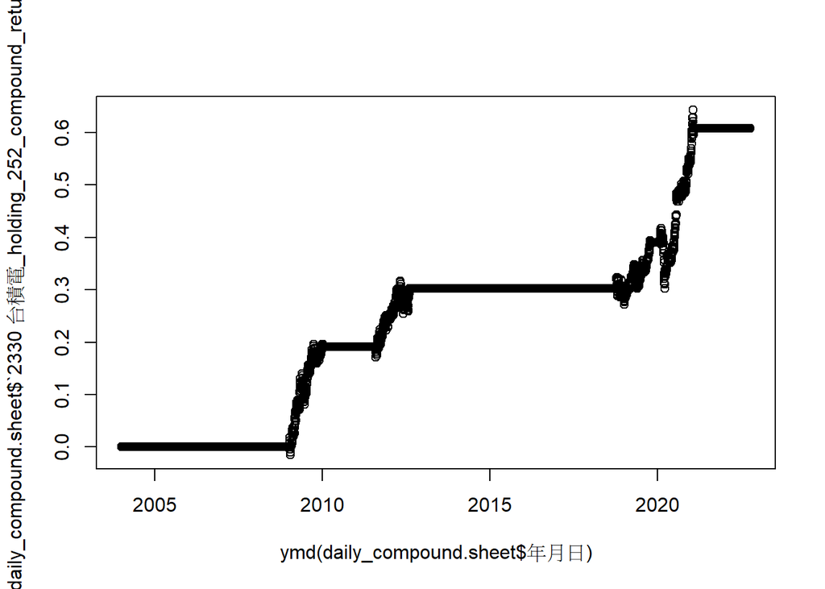

```r
#####畫圖用的表格，取出前幾天的報酬，然後沒有交易的日期給他填0做計算，因為要跟brench_mark比較#####
#接下來要取買進並持有的日期
trade_date = data.table(market_index %>% select(年月日) %>% unique())  #方便實驗組比較使用，先提取出來

#我想要生成一張表格，是現有公司的資料跟時間日期合併，沒有交易的日期daily_change為0
daily_compound.sheet = data.table(年月日 = market_index$年月日 , brench_mark = market_index$brench_mark )

for (n in  ndays){
  for (i in  waited.stock_code){
    tmp = list %>% filter(holding_days == n & stock_code == i) %>% arrange(年月日)
    tmp = merge(tmp ,trade_date , all = T)
    tmp = tmp %>% mutate( stock_code = first(stock_code),
                          #公司名稱 = first(公司名稱),
                          #TSE產業別= first(TSE產業別),
                          holding_days = n ,
                          closed_price_daily_change = ifelse(is.na(closed_price_daily_change),
                                                         0,closed_price_daily_change )
)
tmp = tmp %>% mutate( cumprod_return =  cumprod(closed_price_daily_change + 1 ) -1 )
col.name = paste(i,"_holding_",n,"_compound_return" ,sep = "" )
col.name
tmp = tmp[,.(年月日,cumprod_return)]
colnames(tmp) = c("年月日", col.name)
#print(n)
daily_compound.sheet = merge(daily_compound.sheet , tmp ,by ="年月日" , all = T  )
}
}
plot(y = daily_compound.sheet$`2330 台積電_holding_252_compound_return` ,
     x = ymd(daily_compound.sheet$年月日) )
```

從上述資料中，我們將產業漲幅貢獻最多的台積電拿出來看，，可以發現在買入之後的漲幅驚人，但總報酬仍然不好看，總績效僅60%相較於大盤買進並持有，可以說是差強人意，其原因為大部分的時間都握有現金，沒有參與到股市緩漲的報酬，因此，我們從一些簡單的數據中可以知道，若大盤面臨下跌時，當日下跌5%，又有閒錢時(上班族現金流真讚)，可以考慮半導體產業作為進場的標的，讓資金報酬達到最大化。